# Adult dataset Apriori association rules mining

### Rules mining

Passing parameters of support, confidence accordingly selected for each case and minimal set size = 2 to algorithm in order to avoid rules for every single possible case. Predefining right hand side to get only necessary results.

In first case we are looking for rules leading person to have income 50000 $/year or less.

```r
rules_poor <- apriori(df, parameter = list (support = 0.01,confidence = 0.6, minlen = 2),appearance=list(rhs=c("income=<=50K"),default="lhs"))
```

```
Apriori

Parameter specification:
```

|  | confidence | minval | smax | arem | aval | originalSupport | maxtime | support | minlen | maxlen | target | ext |
| --- | --- | --- | --- | --- | --- | --- | --- | --- | --- | --- | --- | --- |
|  | 0.6 | 0.1 | 1 | none | FALSE | TRUE | 5 | 0.01 | 2 | 10 | rules | TRUE |

```
Algorithmic control:
```

|  | filter | tree | heap | memopt | load | sort | verbose |
| --- | --- | --- | --- | --- | --- | --- | --- |
|  | 0.1 | TRUE | TRUE | FALSE | TRUE | 2 | TRUE |

```
Absolute minimum support count: 301

set item appearances ...[1 item(s)] done [0.00s].
set transactions ...[123 item(s), 30162 transaction(s)] done [0.03s].
sorting and recoding items ... [73 item(s)] done [0.01s].
creating transaction tree ... done [0.02s].
checking subsets of size 1 2 3 4 5 6 7 8 9 10
```

```
 done [2.30s].
writing ... [90454 rule(s)] done [0.07s].
creating S4 object  ... done [0.03s].
```

```r
inspect(rules_poor[1:10])
```

|  | lhs |  | rhs | support | confidence | coverage | lift | count |
| --- | --- | --- | --- | --- | --- | --- | --- | --- |
| [1] | {marital.status=Married-spouse-absent} | => | {income=<=50K} | 0.01123931 | 0.9162162 | 0.01226709 | 1.2198691 | 339 |
| [2] | {education=12th} | => | {income=<=50K} | 0.01153770 | 0.9230769 | 0.01249917 | 1.2290035 | 348 |
| [3] | {education=9th} | => | {income=<=50K} | 0.01425635 | 0.9450549 | 0.01508521 | 1.2582655 | 430 |
| [4] | {education=7th-8th} | => | {income=<=50K} | 0.01730654 | 0.9371634 | 0.01846695 | 1.2477585 | 522 |
| [5] | {native.country=Mexico} | => | {income=<=50K} | 0.01913003 | 0.9459016 | 0.02022412 | 1.2593928 | 577 |
| [6] | {occupation=Protective-serv} | => | {income=<=50K} | 0.01438897 | 0.6739130 | 0.02135137 | 0.8972616 | 434 |
| [7] | {education=10th} | => | {income=<=50K} | 0.02523042 | 0.9280488 | 0.02718653 | 1.2356232 | 761 |
| [8] | {marital.status=Widowed} | => | {income=<=50K} | 0.02476626 | 0.9032648 | 0.02741861 | 1.2026253 | 747 |
| [9] | {relationship=Other-relative} | => | {income=<=50K} | 0.02831377 | 0.9606299 | 0.02947417 | 1.2790024 | 854 |
| [10] | {race=Asian-Pac-Islander} | => | {income=<=50K} | 0.02145083 | 0.7229050 | 0.02967310 | 0.9624906 | 647 |

Visualising data in a more clear way using parallel coordinates plot.

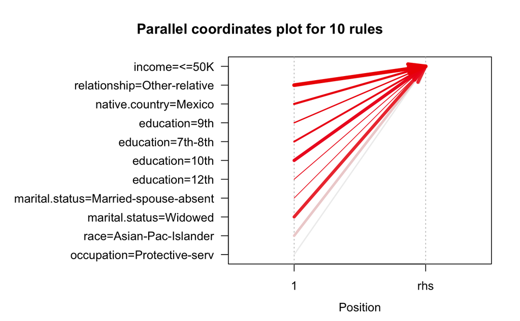

```r
plot(rules_poor[1:10], method = "paracoord")
```

By changing parameters we can get rules for people earning more than 50000 $ per year instead. In this case we have even more detailed information on three level of rules which lets us get more information from research.

```r
rules_rich <- apriori(df, parameter = list (support = 0.05,confidence = 0.5, minlen = 2),appearance=list(rhs=c("income=>50K" ),default="lhs"))
```

```
Apriori

Parameter specification:
```

|  | confidence | minval | smax | arem | aval | originalSupport | maxtime | support | minlen | maxlen | target | ext |
| --- | --- | --- | --- | --- | --- | --- | --- | --- | --- | --- | --- | --- |
|  | 0.5 | 0.1 | 1 | none | FALSE | TRUE | 5 | 0.05 | 2 | 10 | rules | TRUE |

```
Algorithmic control:
```

|  | filter | tree | heap | memopt | load | sort | verbose |
| --- | --- | --- | --- | --- | --- | --- | --- |
|  | 0.1 | TRUE | TRUE | FALSE | TRUE | 2 | TRUE |

```
Absolute minimum support count: 1508

set item appearances ...[1 item(s)] done [0.00s].
set transactions ...[123 item(s), 30162 transaction(s)] done [0.02s].
sorting and recoding items ... [49 item(s)] done [0.01s].
creating transaction tree ... done [0.01s].
checking subsets of size 1 2 3 4 5 6 7 8 9 10
```

```
 done [0.68s].
writing ... [522 rule(s)] done [0.00s].
creating S4 object  ... done [0.01s].
```

```r
inspect(rules_rich[1:10])
```

```
     lhs                                     rhs              support confidence   coverage     lift count
[1]  {marital.status=Married-civ-spouse,
      occupation=Exec-managerial}         => {income=>50K} 0.05424043  0.6830898 0.07940455 2.744187  1636
[2]  {education.num=[10,16],
      occupation=Exec-managerial}         => {income=>50K} 0.05480406  0.5351246 0.10241363 2.149764  1653
[3]  {occupation=Exec-managerial,
      sex=Male}                           => {income=>50K} 0.05503614  0.5826606 0.09445660 2.340731  1660
[4]  {occupation=Exec-managerial,
      hours.per.week=[40,99]}             => {income=>50K} 0.06060606  0.5134831 0.11802931 2.062823  1828
[5]  {education=Bachelors,
      relationship=Husband}               => {income=>50K} 0.05245010  0.6878261 0.07625489 2.763214  1582
[6]  {education=Bachelors,
      marital.status=Married-civ-spouse}  => {income=>50K} 0.05874942  0.6818007 0.08616803 2.739008  1772
[7]  {education=Bachelors,
      sex=Male}                           => {income=>50K} 0.05997613  0.5136286 0.11676944 2.063408  1809
[8]  {education.num=[10,16],
      relationship=Husband}               => {income=>50K} 0.13967907  0.5979279 0.23360520 2.402065  4213
[9]  {education.num=[10,16],
      marital.status=Married-civ-spouse}  => {income=>50K} 0.15761554  0.5968613 0.26407400 2.397780  4754
[10] {marital.status=Married-civ-spouse,
      occupation=Exec-managerial,
      hours.per.week=[40,99]}             => {income=>50K} 0.05099131  0.7006834 0.07277369 2.814866  1538
```

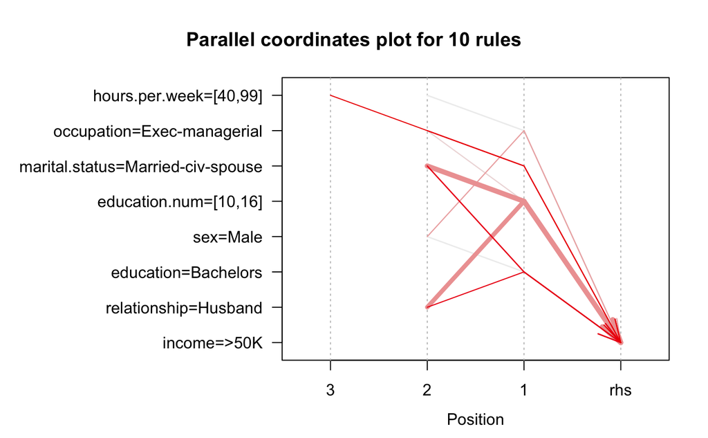

```r
plot(rules_rich[1:10], method= "paracoord")
```

Applying similar set of commands we can easily get other information: for example we can check what might impact marital status of person.

Checking why somebody was never married.

```r
rules_single <- apriori(df, parameter = list (support = 0.05,confidence = 0.5, minlen = 2),appearance=list(rhs=c("marital.status=Never-married"),default="lhs"))
```

```
Apriori

Parameter specification:
```

|  | confidence | minval | smax | arem | aval | originalSupport | maxtime | support | minlen | maxlen | target | ext |
| --- | --- | --- | --- | --- | --- | --- | --- | --- | --- | --- | --- | --- |
|  | 0.5 | 0.1 | 1 | none | FALSE | TRUE | 5 | 0.05 | 2 | 10 | rules | TRUE |

```
Algorithmic control:
```

|  | filter | tree | heap | memopt | load | sort | verbose |
| --- | --- | --- | --- | --- | --- | --- | --- |
|  | 0.1 | TRUE | TRUE | FALSE | TRUE | 2 | TRUE |

```
Absolute minimum support count: 1508

set item appearances ...[1 item(s)] done [0.00s].
set transactions ...[123 item(s), 30162 transaction(s)] done [0.02s].
sorting and recoding items ... [49 item(s)] done [0.01s].
creating transaction tree ... done [0.02s].
checking subsets of size 1 2 3 4 5 6 7 8 9 10
```

```
 done [0.66s].
writing ... [1062 rule(s)] done [0.00s].
creating S4 object  ... done [0.01s].
```

```r
inspect(rules_single[1:15])
```

|  | lhs |  | rhs | support | confidence | coverage | lift | count |
| --- | --- | --- | --- | --- | --- | --- | --- | --- |
| [1] | {age=[17,22)} | => | {marital.status=Never-married} | 0.08185797 | 0.9427262 | 0.08683111 | 2.923556 | 2469 |
| [2] | {age=[22,26)} | => | {marital.status=Never-married} | 0.07671905 | 0.7589374 | 0.10108746 | 2.353595 | 2314 |
| [3] | {age=[26,30)} | => | {marital.status=Never-married} | 0.05347789 | 0.5176508 | 0.10330880 | 1.605324 | 1613 |
| [4] | {occupation=Other-service} | => | {marital.status=Never-married} | 0.05331211 | 0.5006227 | 0.10649161 | 1.552517 | 1608 |
| [5] | {relationship=Own-child} | => | {marital.status=Never-married} | 0.13026325 | 0.8797582 | 0.14806710 | 2.728282 | 3929 |
| [6] | {hours.per.week=[1,40)} | => | {marital.status=Never-married} | 0.11153107 | 0.5010426 | 0.22259797 | 1.553819 | 3364 |
| [7] | {relationship=Not-in-family} | => | {marital.status=Never-married} | 0.14747033 | 0.5757184 | 0.25615012 | 1.785402 | 4448 |
| [8] | {age=[17,22), relationship=Own-child} | => | {marital.status=Never-married} | 0.05987667 | 0.9831247 | 0.06090445 | 3.048839 | 1806 |
| [9] | {age=[17,22), hours.per.week=[1,40)} | => | {marital.status=Never-married} | 0.05354419 | 0.9728916 | 0.05503614 | 3.017104 | 1615 |
| [10] | {age=[17,22), workclass=Private} | => | {marital.status=Never-married} | 0.07429879 | 0.9419924 | 0.07887408 | 2.921281 | 2241 |

[output cut: 5 more lines]

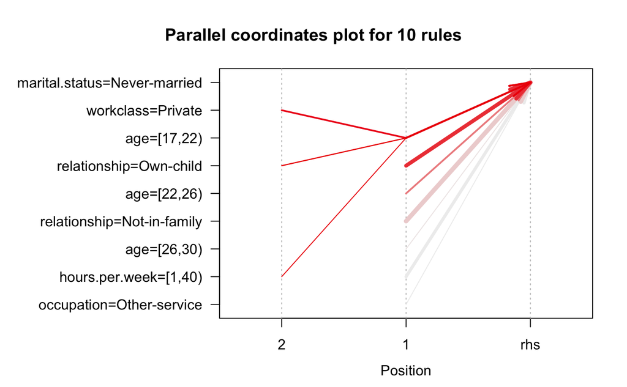

```r
plot(rules_single[1:10], method= "paracoord")
```

And what might be the reason for marriage.

```r
rules_married <- apriori(df, parameter = list (support = 0.05,confidence = 0.5, minlen = 2),appearance=list(rhs=c("marital.status=Married-civ-spouse","marital.status=Married-spouse-absent","marital.status=Married-AF-spouse"),default="lhs"))
```

```
Apriori

Parameter specification:
```

|  | confidence | minval | smax | arem | aval | originalSupport | maxtime | support | minlen | maxlen | target | ext |
| --- | --- | --- | --- | --- | --- | --- | --- | --- | --- | --- | --- | --- |
|  | 0.5 | 0.1 | 1 | none | FALSE | TRUE | 5 | 0.05 | 2 | 10 | rules | TRUE |

```
Algorithmic control:
```

|  | filter | tree | heap | memopt | load | sort | verbose |
| --- | --- | --- | --- | --- | --- | --- | --- |
|  | 0.1 | TRUE | TRUE | FALSE | TRUE | 2 | TRUE |

```
Absolute minimum support count: 1508

set item appearances ...[3 item(s)] done [0.00s].
set transactions ...[123 item(s), 30162 transaction(s)] done [0.03s].
sorting and recoding items ... [49 item(s)] done [0.01s].
creating transaction tree ... done [0.01s].
checking subsets of size 1 2 3 4 5 6 7 8 9 10
```

```
 done [0.66s].
writing ... [5306 rule(s)] done [0.00s].
creating S4 object  ... done [0.01s].
```

```r
inspect(rules_married[1:15])
```

|  | lhs |  | rhs | support | confidence | coverage | lift | count |
| --- | --- | --- | --- | --- | --- | --- | --- | --- |
| [1] | {workclass=Self-emp-not-inc} | => | {marital.status=Married-civ-spouse} | 0.05487037 | 0.6622649 | 0.08285260 | 1.420209 | 1655 |
| [2] | {age=[41,45)} | => | {marital.status=Married-civ-spouse} | 0.05758902 | 0.5874197 | 0.09803727 | 1.259705 | 1737 |
| [3] | {age=[57,90]} | => | {marital.status=Married-civ-spouse} | 0.06276109 | 0.6116317 | 0.10261256 | 1.311627 | 1893 |
| [4] | {age=[37,41)} | => | {marital.status=Married-civ-spouse} | 0.05994297 | 0.5703470 | 0.10509913 | 1.223093 | 1808 |
| [5] | {age=[50,57)} | => | {marital.status=Married-civ-spouse} | 0.06750216 | 0.6418663 | 0.10516544 | 1.376464 | 2036 |
| [6] | {age=[45,50)} | => | {marital.status=Married-civ-spouse} | 0.06289371 | 0.5969163 | 0.10536437 | 1.280070 | 1897 |
| [7] | {age=[33,37)} | => | {marital.status=Married-civ-spouse} | 0.05795372 | 0.5213242 | 0.11116637 | 1.117965 | 1748 |
| [8] | {occupation=Exec-managerial} | => | {marital.status=Married-civ-spouse} | 0.07940455 | 0.5999499 | 0.13235197 | 1.286576 | 2395 |
| [9] | {occupation=Craft-repair} | => | {marital.status=Married-civ-spouse} | 0.08368145 | 0.6263027 | 0.13361183 | 1.343089 | 2524 |
| [10] | {occupation=Prof-specialty} | => | {marital.status=Married-civ-spouse} | 0.06849678 | 0.5116394 | 0.13387706 | 1.097196 | 2066 |

[output cut: 5 more lines]

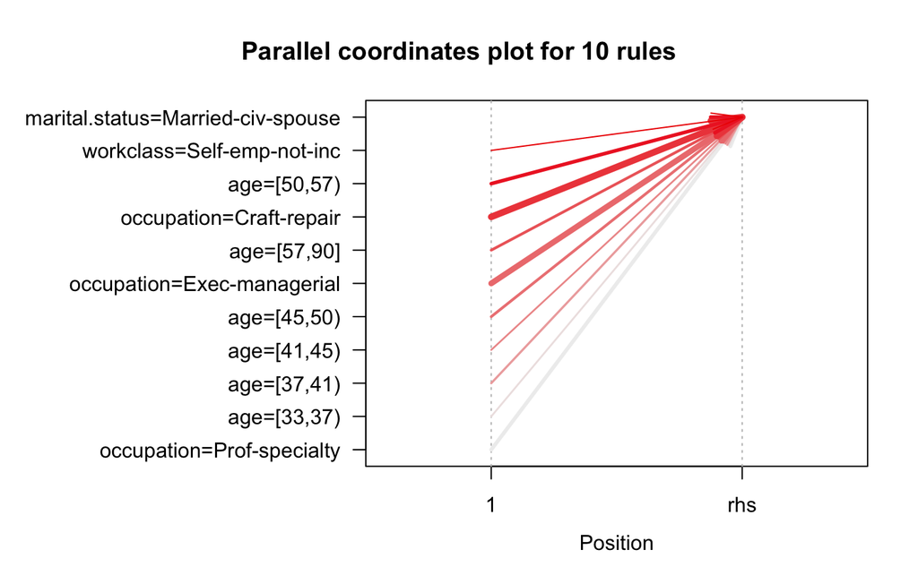

```r
plot(rules_married[1:10], method= "paracoord")
```

### Conclusion

Apriori algorithm is a powerful tool to find association rules which let us gain an understanding of what is the reason for something.